# ANALISI GEOSTATISTICA DEI DATI AMBIENTALI – Livello intermedio (T28_25_3_2)

# ANALISI GEOSTATISTICA DEI DATI AMBIENTALI – Livello intermedio

## Riferimenti utili

**CRS** - coordinate reference system

https://r.geocompx.org/spatial-class#crs-intro  
https://r-spatial.org/book/02-Spaces.html#sec-crs  
**meuse dataset** - https://cloud.r-project.org/web/packages/gstat/vignettes/gstat.pdf

veneto dataset in cartella “**dati**”  
metodi di interpolazione geografica - https://r-spatial.org/book/12-Interpolation.html

#### Applied Spatial Data Analysis with R (Bivand et al.) - https://gis.humboldt.edu/OLM/r/Spatial%20Analysis%20With%20R.pdf

## Obiettivo

Seguiremo il testo “Applied Spatial Data Analysis with R” di Bivand, Pebesma e Gómez-Rubio (vedi link sopra)

## Giornata 1

- Ripasso basi teoriche, analisi esplorativa dei dati per verifiche presupposti al Kriging
- Richiamo sulle statistiche descrittive, distribuzioni, trasformazioni, sistemi di riferimento
- Richiamo geostatistica: variabili regionalizzate, autocorrelazione spaziale
- Il variogramma: definizione, semivarianza, sperimentale vs modello, legame con la continuità spaziale.

## Giornata 2

- Calcolo dell’autocorrelazione (es. indice di Moran) e del variogramma sperimentale - dati del veneto - esercizio da consegnare
- Discussione: “Cosa ci dice il variogramma? Quali sono i punti deboli (campionamento, anisotropia, non stazionarietà)?”
- Interpolazione (kriging) e stima spaziale - cokriging, block kriging, collocated kriging, global vs local kriging, indicator kriging
- Introduzione alla validazione

## Giornata 3

- Esercizi con tipologie diverse di Kriging
- Valutazione dell’incertezza
- Validazione (cross validation)

## Dati di esempio

Useremo il dataset “meuse” e “veneto” e le librerie che vedete sotto

```r
library(lattice)
library(tidyverse)
library(stats)
library(ggplot2)
library(terra)
library(gstat)
library(kableExtra)
library(sp)
data(meuse)
#class(meuse)

kable(head(meuse, 5), caption = "Dataset *meuse*") %>%
  kable_styling(full_width = FALSE, bootstrap_options = c("striped", "hover"))%>%
  kable_styling(latex_options = "scale_down")
```

Dataset *meuse*

| x | y | cadmium | copper | lead | zinc | elev | dist | om | ffreq | soil | lime | landuse | dist.m |
| --- | --- | --- | --- | --- | --- | --- | --- | --- | --- | --- | --- | --- | --- |
| 181072 | 333611 | 11.7 | 85 | 299 | 1022 | 7.909 | 0.0013580 | 13.6 | 1 | 1 | 1 | Ah | 50 |
| 181025 | 333558 | 8.6 | 81 | 277 | 1141 | 6.983 | 0.0122243 | 14.0 | 1 | 1 | 1 | Ah | 30 |
| 181165 | 333537 | 6.5 | 68 | 199 | 640 | 7.800 | 0.1030290 | 13.0 | 1 | 1 | 1 | Ah | 150 |
| 181298 | 333484 | 2.6 | 81 | 116 | 257 | 7.655 | 0.1900940 | 8.0 | 1 | 2 | 0 | Ga | 270 |
| 181307 | 333330 | 2.8 | 48 | 117 | 269 | 7.480 | 0.2770900 | 8.7 | 1 | 2 | 0 | Ah | 380 |

Esercizio: provate a replicare quanto sotto con il dataset “Veneto” che trovate nel file CSV

pg 192 del testo [Applied Spatial Data Analysis with R (Bivand et al.) - https://gis.humboldt.edu/OLM/r/Spatial%20Analysis%20With%20R.pdf]

[ Trovate i dati climatici del veneto in formato CSV nella cartella “dati”… il CRS dei dati del Veneto è il 3003 (Gauss Boaga Fuso Ovest)]

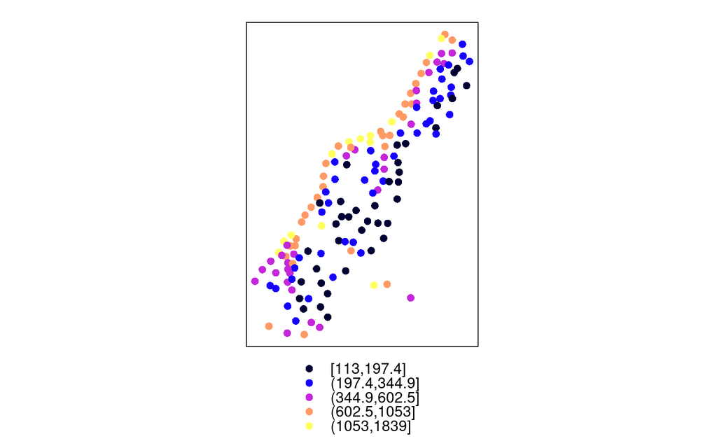

```r
data(meuse)
coordinates(meuse) <- c("x", "y")
spplot(meuse, "zinc", do.log = T)
```

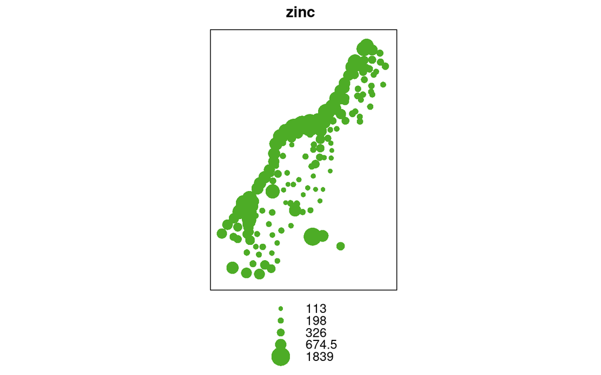

```r
bubble(meuse, "zinc", do.log = T, key.space = "bottom")
```

## Analisi Esplorativa dei dati

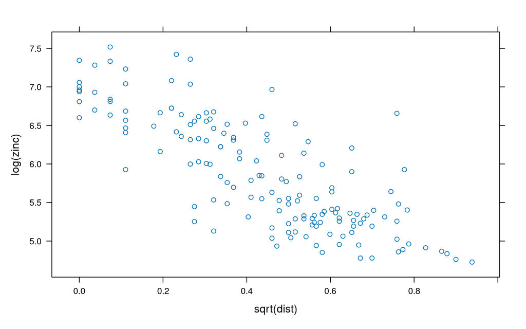

```r
library(lattice)
 xyplot(log(zinc) ~ sqrt(dist), as.data.frame(meuse))
```

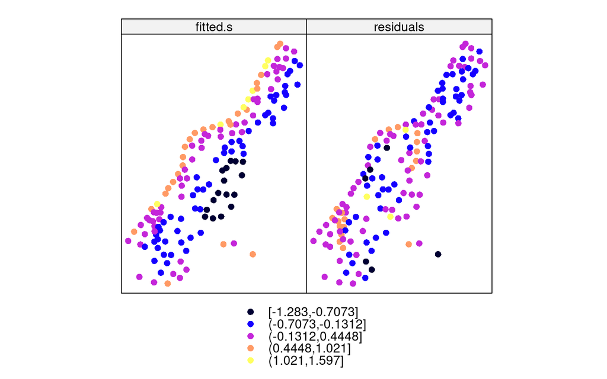

```r
 zn.lm <- lm(log(zinc) ~ sqrt(dist), meuse)
 meuse$fitted.s <- predict(zn.lm, meuse) - mean(predict(zn.lm, meuse))
meuse$residuals <- residuals(zn.lm)
spplot(meuse, c("fitted.s", "residuals"))
```

```r
# spplot(meuse, c("fitted.s"))
# spplot(meuse, c("residuals"))
```

## Interpolazioni con metodo deterministico

### Inverso della distanza

Attenzione usiamo idw esprimendolo usando gstat::idw in quanto altri packages in R hanno la funzione IDW e può causare confusione ed errori

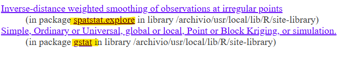

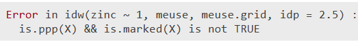

```r
library(gstat)
data(meuse.grid)
coordinates(meuse.grid) <- c("x", "y")
meuse.grid <- as(meuse.grid, "SpatialPixelsDataFrame")

idw.out <- gstat::idw(zinc ~ 1, meuse, meuse.grid, idp = 2.5)
```

```
## [inverse distance weighted interpolation]
```

### Interpolazione lineare o non-lineare

```r
zn.lm <- lm(log(zinc) ~ sqrt(dist), meuse)
meuse.grid$pred <- predict(zn.lm, meuse.grid)
meuse.grid$se.fit <- predict(zn.lm, meuse.grid, se.fit = TRUE)$se.fit
### oppure
meuse.tr2 <- krige(log(zinc) ~ 1, meuse, meuse.grid, degree = 2)
```

```
## [ordinary or weighted least squares prediction]
```

```r
## oppure
lm(log(zinc) ~ I(x^2) + I(y^2) + I(x * y) + x + y, meuse)
```

```
##
## Call:
## lm(formula = log(zinc) ~ I(x^2) + I(y^2) + I(x * y) + x + y,
##     data = meuse)
##
## Coefficients:
## (Intercept)       I(x^2)       I(y^2)     I(x * y)            x            y
##   2.395e+04    8.575e-07    8.467e-07   -1.623e-06    2.279e-01   -2.684e-01
```